# A Vignette to Bootstrap Panel Quantile Regression

Riki Saito

December 3, 2015

First, we will view the summary of the example data used in this vignette.

```
##     Station        Segment           Year          Precip
##  5438500:  70   Min.   :0.000   1968   : 109   Min.   :0.000024
##  5439500:  70   1st Qu.:1.000   1969   : 109   1st Qu.:0.717553
##  5447500:  70   Median :1.000   1970   : 109   Median :1.170675
##  5545750:  70   Mean   :1.121   1971   : 109   Mean   :1.270443
##  5540500:  69   3rd Qu.:1.000   1972   : 109   3rd Qu.:1.597410
##  5542000:  69   Max.   :4.000   1966   : 108   Max.   :6.455270
##  (Other):3646                   (Other):3411
##    Urban.Frac      Present.Urban.Frac Original.Peaks
##  Min.   :0.00000   Min.   :0.0000     Min.   :    3
##  1st Qu.:0.06173   1st Qu.:0.1958     1st Qu.:  185
##  Median :0.25994   Median :0.5798     Median :  502
##  Mean   :0.33843   Mean   :0.5263     Mean   : 1251
##  3rd Qu.:0.58403   3rd Qu.:0.8220     3rd Qu.: 1270
##  Max.   :0.98398   Max.   :1.0000     Max.   :25400
##
```

Let us first examine the relationship of the response with the predictor, and the boxplot of the response by “firm” levels to motivate the use of a panel quantile regression.

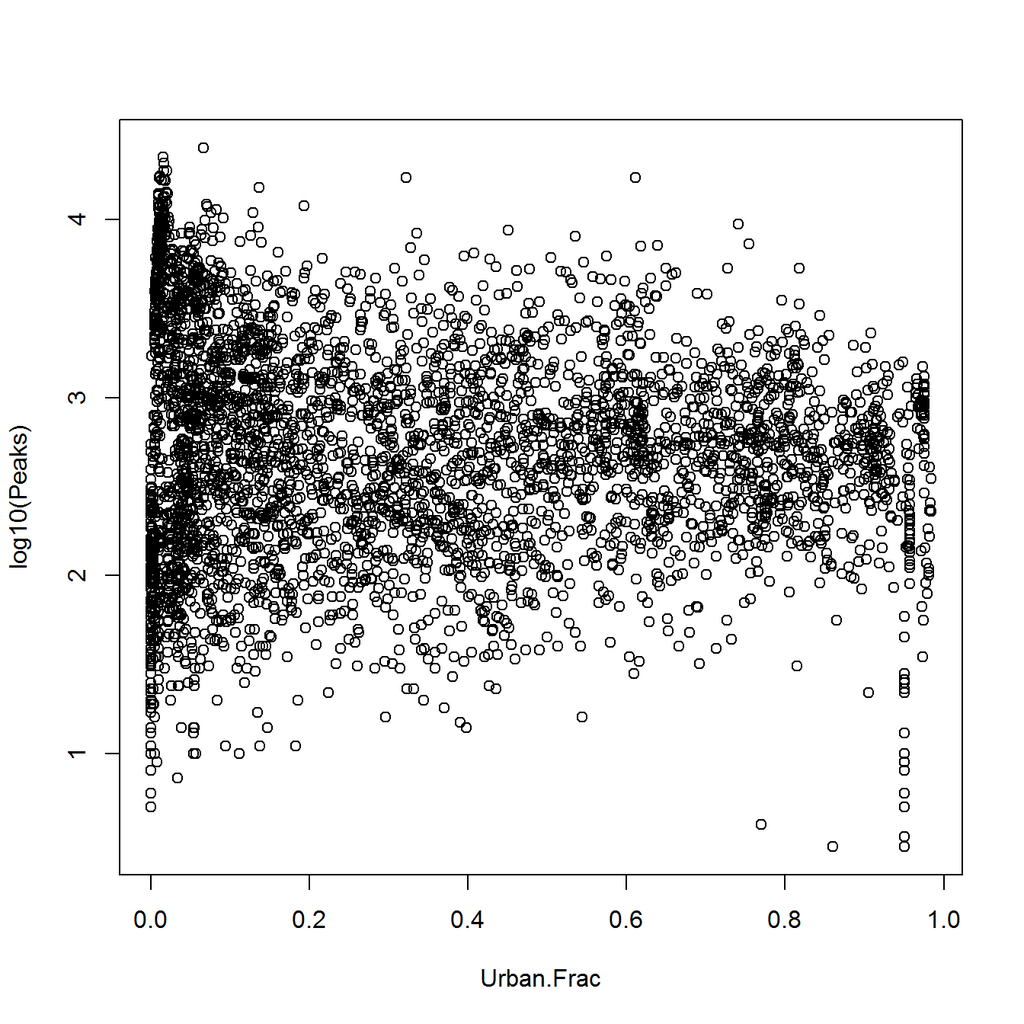

```r
# Motivation for method
plot(data$Urban.Frac, log10(data$Original.Peaks), xlab="Urban.Frac",ylab="log10(Peaks)")
```

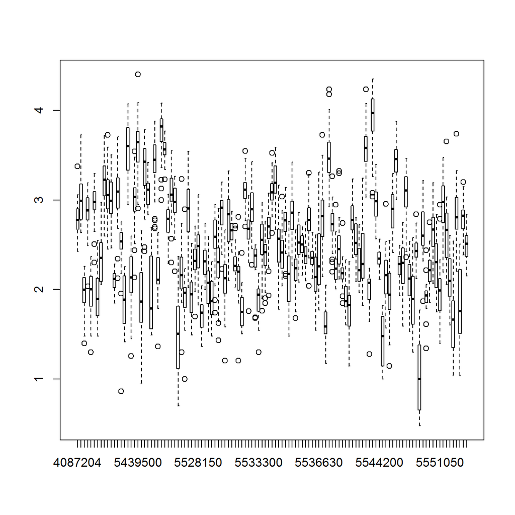

```r
boxplot(log10(Original.Peaks) ~ Station, data)
```

We can argue the use of a quantile regression from the first plot, and the use of a panel regression from the second plot. Now let us try applying a panel quantile regression on this data. The first step is to perform a fixed effects panel regression on this data.

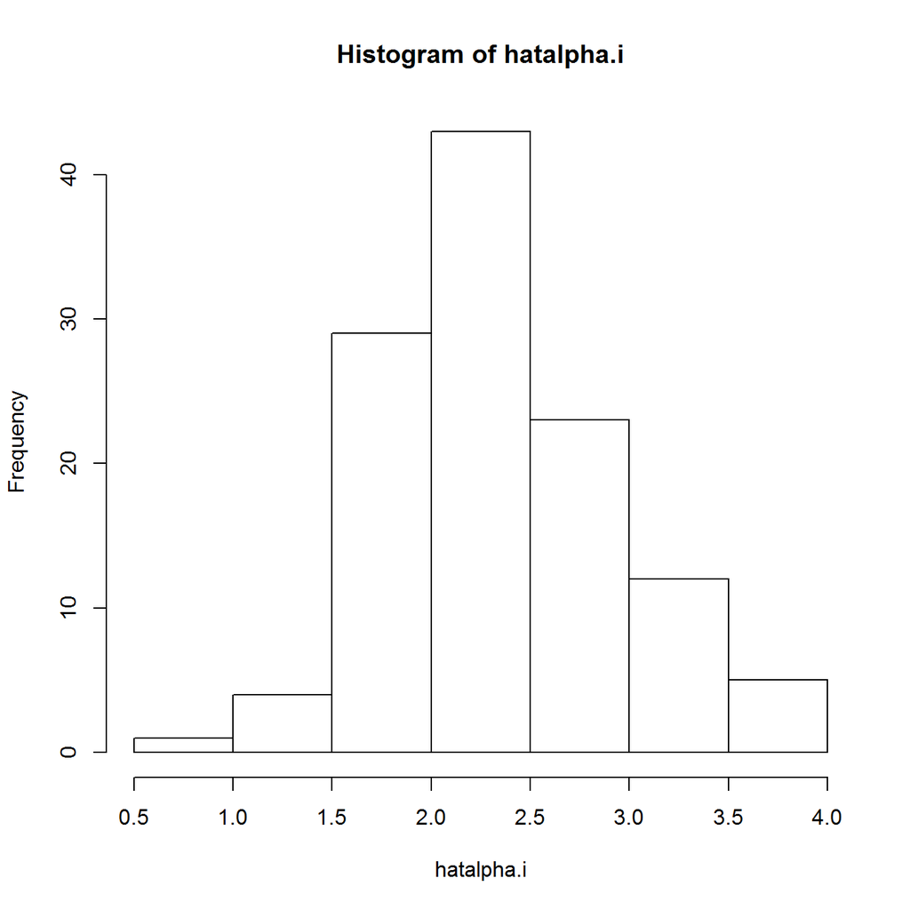

```r
formula = log10(Original.Peaks) ~ Urban.Frac;
plm  <- plm(formula,data=data,model="within");
prelim  <- cbind(coef(plm));    # This vector is K x 1 - only slopes.

hatalpha.i  <- cbind(fixef(plm));                         # dimension n x 1
all.firm <- gsub( "-.*$|\\..*$", "", row.names(data))
all.firm.fe <- merge(cbind(table(all.firm)),cbind(hatalpha.i), by="row.names")
intercept <- sum(row.prod(all.firm.fe[,-1]))/nrow(data)  #weighted mean of fixed effects
adj.hatalpha <- rep(hatalpha.i, table(all.firm)) - intercept
hist(hatalpha.i)
```

From the panel regression, we can see the varying intercepts of different “firms”. We will remove this heterogeneity in the response, and the apply quantile regression.

```r
tau = c(.01,.05,seq(.1,.9,by=.1),.95,.99)
mf <- model.frame(formula, data)
y <- model.response(mf, "numeric")
x <- model.matrix(formula, data)
y.adj <- y - adj.hatalpha     #new y values adjusted for fixed effects
fm <- update.formula(formula, as.formula('y.adj ~ .'))
index = names(attr(data,"index"))
rqdf <- pdata.frame(cbind(data,y.adj),index=index)   #might need to edit
z <- rq(fm, data=rqdf, tau)
#z <- rq(y.adj~., data=data.frame(y.adj,x[,-1]), tau)
z$fe <- hatalpha.i
z
```

```
## Call:
## rq(formula = fm, tau = tau, data = rqdf)
##
## Coefficients:
##             tau= 0.01 tau= 0.05 tau= 0.10 tau= 0.20 tau= 0.30 tau= 0.40
## (Intercept) 1.7574098 2.0192620 2.1836002 2.3292450 2.4237670 2.4982138
## Urban.Frac  0.8245286 0.7126698 0.5965053 0.5179786 0.4781038 0.4449967
##             tau= 0.50 tau= 0.60 tau= 0.70 tau= 0.80 tau= 0.90 tau= 0.95
## (Intercept) 2.5540395 2.6077825 2.6744599 2.7555898 2.8575315 2.9627968
## Urban.Frac  0.4336063 0.4237011 0.4076257 0.3699474 0.3657407 0.3708973
##             tau= 0.99
## (Intercept) 3.2196072
## Urban.Frac  0.2976004
##
## Degrees of freedom: 4064 total; 4062 residual
```

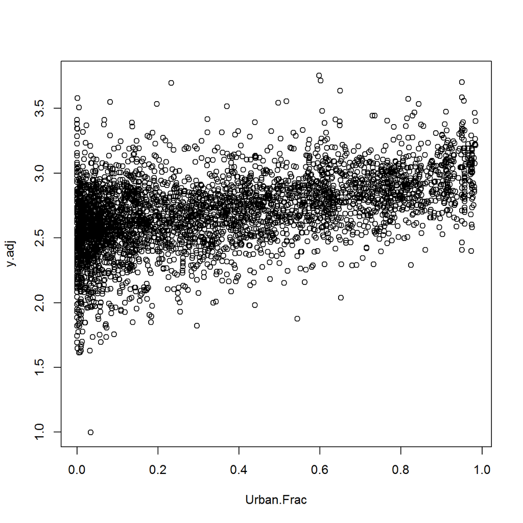

```r
plot(data$Urban.Frac, y.adj, xlab="Urban.Frac")
```

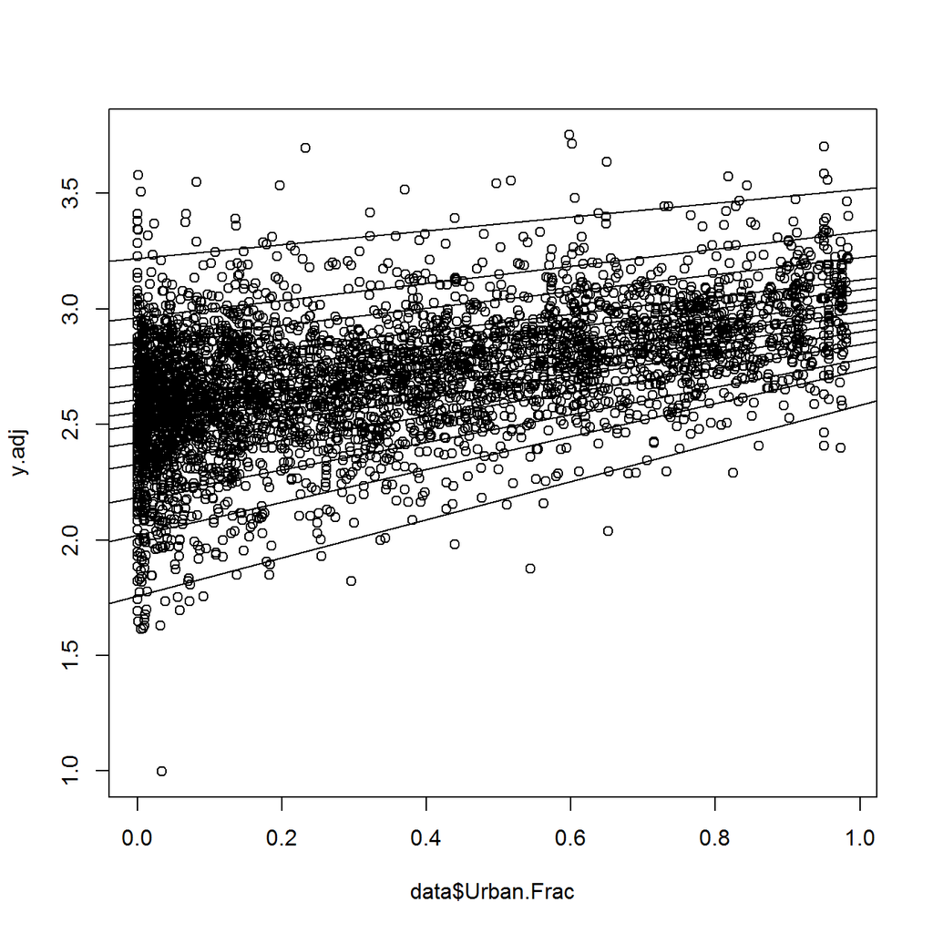

```r
plot(data$Urban.Frac, y.adj)
for(i in seq_len(length(tau))) abline(coef(z)[1,i],coef(z)[2,i])
```

Now with bootstrapping

```
## Bootstrap Complete.
## Time elapsed:  13.031 seconds
```

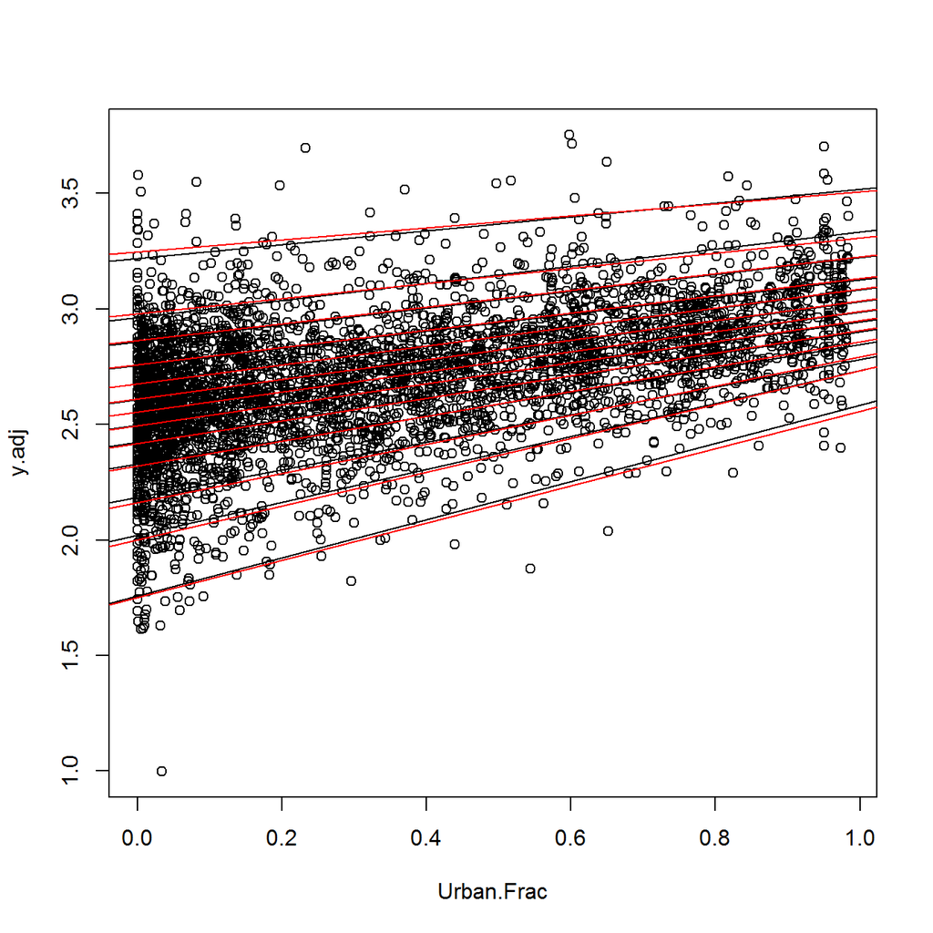

# A Vignette to Bootstrap Panel Quantile Regression

Riki Saito

December 3, 2015

First, we will view the summary of the example data used in this vignette.

```
##     Station        Segment           Year          Precip
##  5438500:  70   Min.   :0.000   1968   : 109   Min.   :0.000024
##  5439500:  70   1st Qu.:1.000   1969   : 109   1st Qu.:0.717553
##  5447500:  70   Median :1.000   1970   : 109   Median :1.170675
##  5545750:  70   Mean   :1.121   1971   : 109   Mean   :1.270443
##  5540500:  69   3rd Qu.:1.000   1972   : 109   3rd Qu.:1.597410
##  5542000:  69   Max.   :4.000   1966   : 108   Max.   :6.455270
##  (Other):3646                   (Other):3411
##    Urban.Frac      Present.Urban.Frac Original.Peaks
##  Min.   :0.00000   Min.   :0.0000     Min.   :    3
##  1st Qu.:0.06173   1st Qu.:0.1958     1st Qu.:  185
##  Median :0.25994   Median :0.5798     Median :  502
##  Mean   :0.33843   Mean   :0.5263     Mean   : 1251
##  3rd Qu.:0.58403   3rd Qu.:0.8220     3rd Qu.: 1270
##  Max.   :0.98398   Max.   :1.0000     Max.   :25400
##
```

Let us first examine the relationship of the response with the predictor, and the boxplot of the response by “firm” levels to motivate the use of a panel quantile regression.

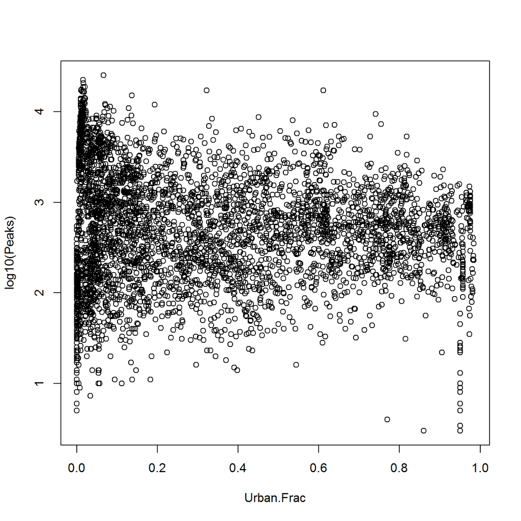

```r
# Motivation for method
plot(data$Urban.Frac, log10(data$Original.Peaks), xlab="Urban.Frac",ylab="log10(Peaks)")
```

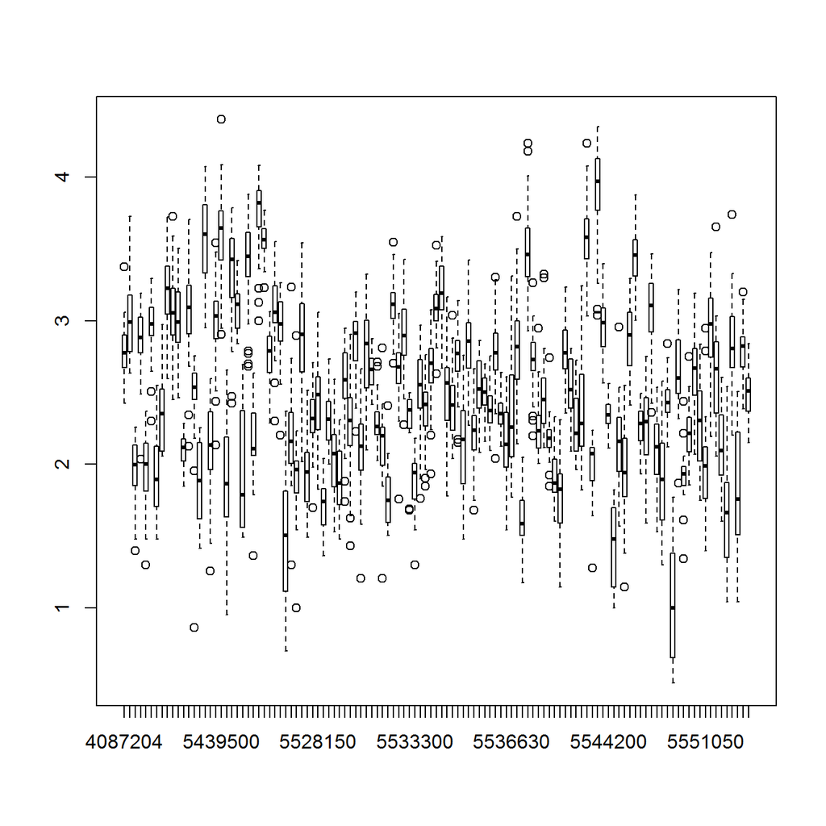

```r
boxplot(log10(Original.Peaks) ~ Station, data)
```

We can argue the use of a quantile regression from the first plot, and the use of a panel regression from the second plot. Now let us try applying a panel quantile regression on this data. The first step is to perform a fixed effects panel regression on this data.

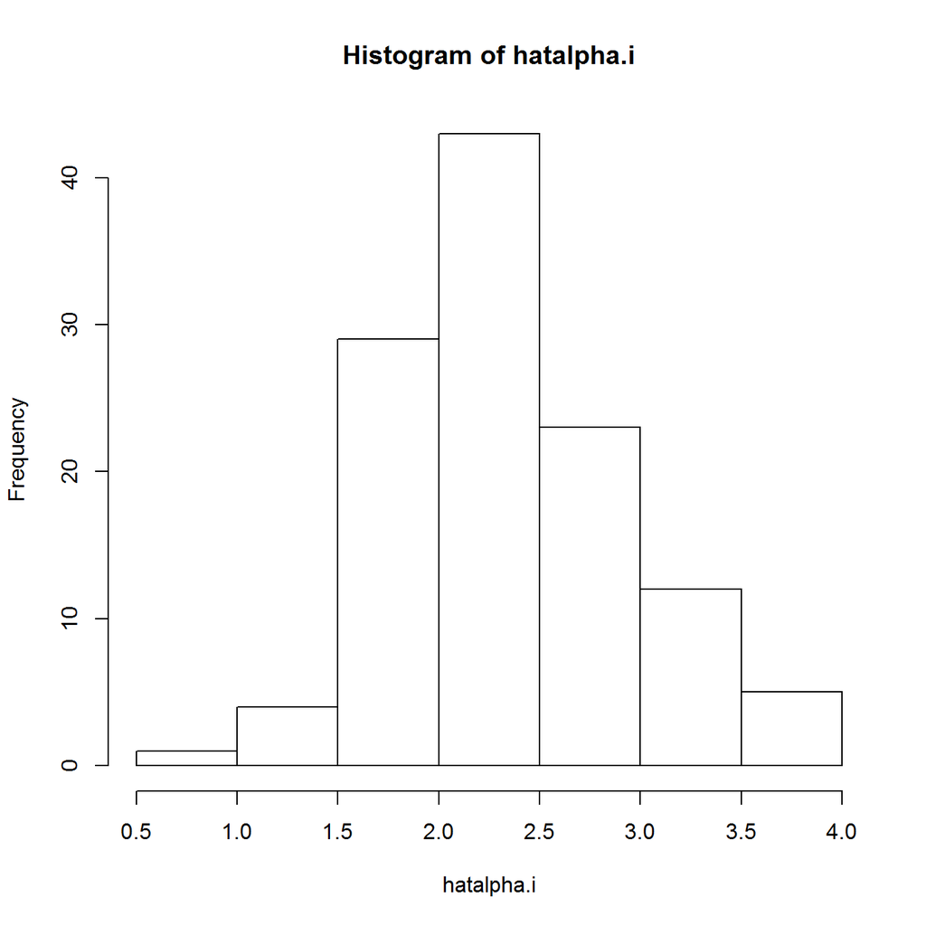

```r
formula = log10(Original.Peaks) ~ Urban.Frac;
plm  <- plm(formula,data=data,model="within");
prelim  <- cbind(coef(plm));    # This vector is K x 1 - only slopes.

hatalpha.i  <- cbind(fixef(plm));                         # dimension n x 1
all.firm <- gsub( "-.*$|\\..*$", "", row.names(data))
all.firm.fe <- merge(cbind(table(all.firm)),cbind(hatalpha.i), by="row.names")
intercept <- sum(row.prod(all.firm.fe[,-1]))/nrow(data)  #weighted mean of fixed effects
adj.hatalpha <- rep(hatalpha.i, table(all.firm)) - intercept
hist(hatalpha.i)
```

From the panel regression, we can see the varying intercepts of different “firms”. We will remove this heterogeneity in the response, and the apply quantile regression.

```r
tau = c(.01,.05,seq(.1,.9,by=.1),.95,.99)
mf <- model.frame(formula, data)
y <- model.response(mf, "numeric")
x <- model.matrix(formula, data)
y.adj <- y - adj.hatalpha     #new y values adjusted for fixed effects
fm <- update.formula(formula, as.formula('y.adj ~ .'))
index = names(attr(data,"index"))
rqdf <- pdata.frame(cbind(data,y.adj),index=index)   #might need to edit
z <- rq(fm, data=rqdf, tau)
#z <- rq(y.adj~., data=data.frame(y.adj,x[,-1]), tau)
z$fe <- hatalpha.i
z
```

```
## Call:
## rq(formula = fm, tau = tau, data = rqdf)
##
## Coefficients:
##             tau= 0.01 tau= 0.05 tau= 0.10 tau= 0.20 tau= 0.30 tau= 0.40
## (Intercept) 1.7574098 2.0192620 2.1836002 2.3292450 2.4237670 2.4982138
## Urban.Frac  0.8245286 0.7126698 0.5965053 0.5179786 0.4781038 0.4449967
##             tau= 0.50 tau= 0.60 tau= 0.70 tau= 0.80 tau= 0.90 tau= 0.95
## (Intercept) 2.5540395 2.6077825 2.6744599 2.7555898 2.8575315 2.9627968
## Urban.Frac  0.4336063 0.4237011 0.4076257 0.3699474 0.3657407 0.3708973
##             tau= 0.99
## (Intercept) 3.2196072
## Urban.Frac  0.2976004
##
## Degrees of freedom: 4064 total; 4062 residual
```

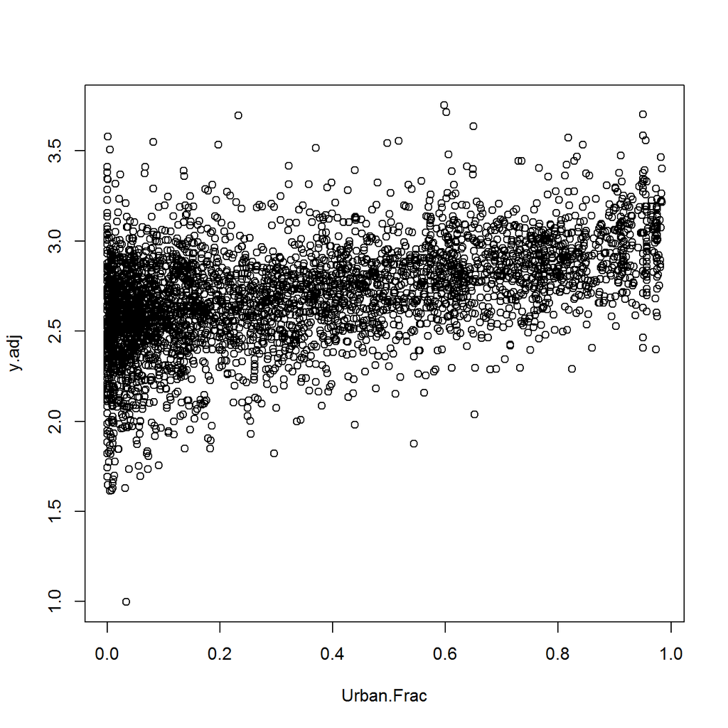

```r
plot(data$Urban.Frac, y.adj, xlab="Urban.Frac")
```

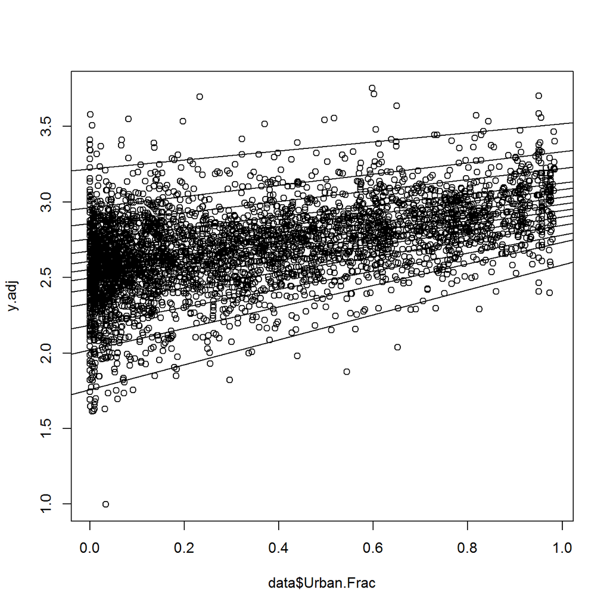

```r
plot(data$Urban.Frac, y.adj)
for(i in seq_len(length(tau))) abline(coef(z)[1,i],coef(z)[2,i])
```

Now with bootstrapping

```
## Bootstrap Complete.
## Time elapsed:  15.056 seconds
```

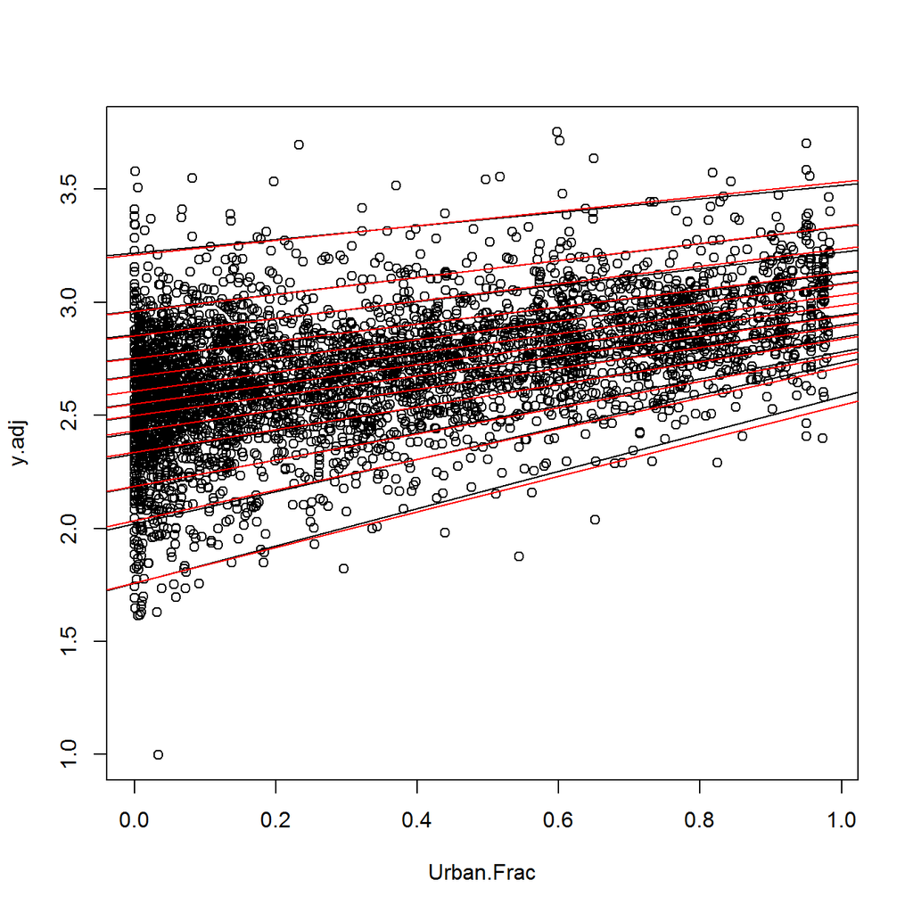